# Lab7

### 7.2 Analisis segundo modelo

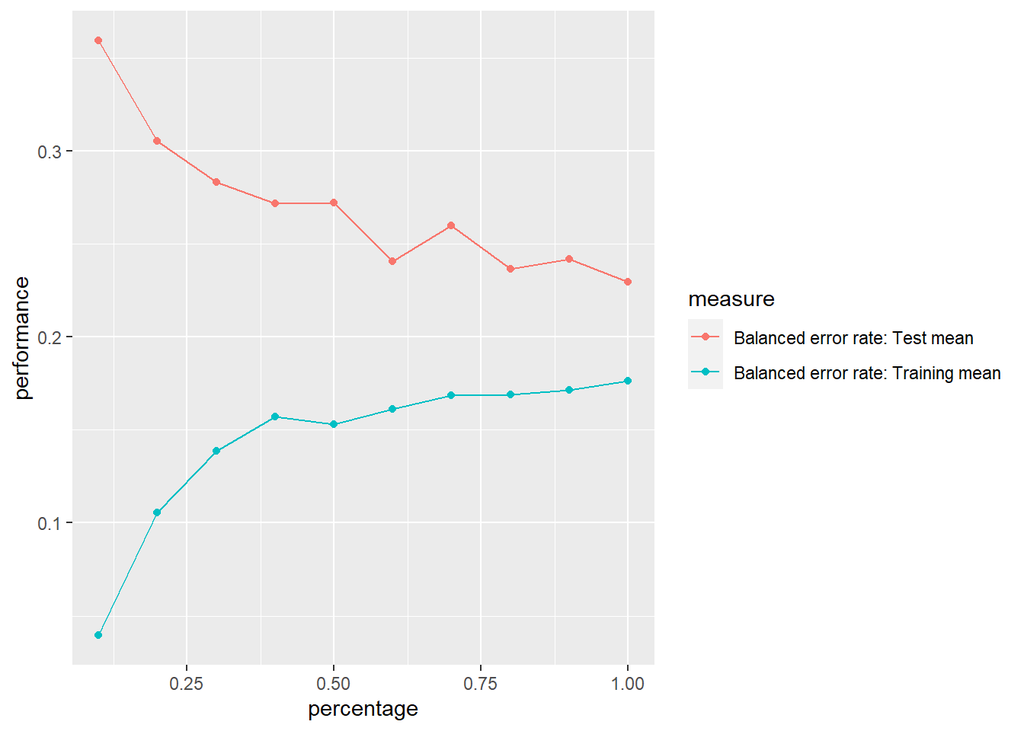

```r
    datos.task = makeClassifTask(data = train, target = "clasificacion")
    rin2 = makeResampleDesc(method = "CV", iters = 10, predict = "both")
    lrn = makeLearner("classif.svm", kernel = "linear", cost = 0.5, type = "C-classification")
    lc2 = generateLearningCurveData(learners = lrn, task = datos.task,
                                    percs = seq(0.1, 1, by = 0.1),
                                    measures = list(ber, setAggregation(ber, train.mean)), resampling = rin2,
                                    show.info = FALSE)
    plotLearningCurve(lc2, facet = "learner")
```

Al momento de realizar la grafica se puede visualizar que la curva de training y la de test convergen hacia un mismo punto por lo que se puede conlcluir que este modelo no sufre de overfitting ni underfitting.

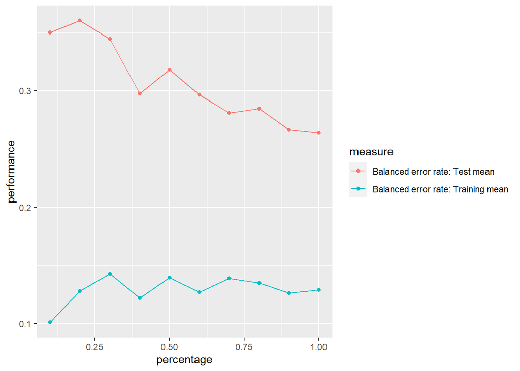

```r
    datos.task = makeClassifTask(data = train, target = "clasificacion")
    rin2 = makeResampleDesc(method = "CV", iters = 10, predict = "both")
    lrn = makeLearner("classif.svm", kernel = "radial", cost = 1, gamma = 2^-5, type = "C-classification")
    lc2 = generateLearningCurveData(learners = lrn, task = datos.task,
                                    percs = seq(0.1, 1, by = 0.1),
                                    measures = list(ber, setAggregation(ber, train.mean)), resampling = rin2,
                                    show.info = FALSE)
    plotLearningCurve(lc2, facet = "learner")
```

Al momento de realizar la grafica se puede mencionar que el modelo sufre de overtfitting esto debido a que primero la curva de training sigue una pequena tendencia a una linea recta y se puede mencionar que esta y la curva de test estan muy alejadas.

## 10. Generar un modelo de regresion

### 10.1 Modelo de Regresion lineal Simple

```r
Modelo_lineal_simple <-lm(SalePrice~OverallQual,data = train)
```

### Resumen del modelo

```r
summary(Modelo_lineal_simple)
```

```
##
## Call:
## lm(formula = SalePrice ~ OverallQual, data = train)
##
## Residuals:
##     Min      1Q  Median      3Q     Max
## -2.4139 -0.3619 -0.0109  0.2543  4.7549
##
## Coefficients:
##             Estimate Std. Error t value Pr(>|t|)
## (Intercept) -0.02778    0.02112  -1.316    0.189
## OverallQual  0.77808    0.02166  35.916   <2e-16 ***
## ---
## Signif. codes:  0 '***' 0.001 '**' 0.01 '*' 0.05 '.' 0.1 ' ' 1
##
## Residual standard error: 0.5913 on 782 degrees of freedom
## Multiple R-squared:  0.6226, Adjusted R-squared:  0.6221
## F-statistic:  1290 on 1 and 782 DF,  p-value: < 2.2e-16
```

### RMSE

```r
PrediccionSimple <-predict(Modelo_lineal_simple,newdata = test)
RMSE(PrediccionSimple,test$SalePrice)
```

```
## [1] 0.6326996
```

### 10.2 Modelo de Regresion Multivariable

```r
Modelo_multiV <- lm(train$SalePrice~., data = train)
```

### Resumen del modelo

```r
summary(Modelo_multiV)
```

```
##
## Call:
## lm(formula = train$SalePrice ~ ., data = train)
##
## Residuals:
##     Min      1Q  Median      3Q     Max
## -3.5052 -0.2023 -0.0236  0.1860  3.4924
##
## Coefficients: (2 not defined because of singularities)
##                            Estimate Std. Error t value Pr(>|t|)
## (Intercept)               0.0760806  0.0274502   2.772 0.005717 **
## MSSubClass               -0.1045898  0.0193461  -5.406 8.67e-08 ***
## LotFrontage              -0.0522736  0.0195559  -2.673 0.007681 **
## LotArea                   0.0556182  0.0163308   3.406 0.000695 ***
## OverallQual               0.2918004  0.0291927   9.996  < 2e-16 ***
## OverallCond               0.0509155  0.0205333   2.480 0.013370 *
## YearBuilt                 0.1181998  0.0377006   3.135 0.001784 **
## YearRemodAdd              0.0427009  0.0252613   1.690 0.091375 .
## MasVnrArea                0.0616581  0.0188321   3.274 0.001109 **
## BsmtFinSF1                0.0385827  0.0365452   1.056 0.291422
## BsmtFinSF2                0.0051185  0.0176796   0.290 0.772268
## BsmtUnfSF                 0.0162193  0.0329115   0.493 0.622288
## TotalBsmtSF                      NA         NA      NA       NA
## X1stFlrSF                 0.1379169  0.0387162   3.562 0.000391 ***
## X2ndFlrSF                 0.1546144  0.0367891   4.203 2.96e-05 ***
## LowQualFinSF              0.0350299  0.0160366   2.184 0.029246 *
## GrLivArea                        NA         NA      NA       NA
## BsmtFullBath              0.0824783  0.0224989   3.666 0.000264 ***
## BsmtHalfBath              0.0311713  0.0159077   1.960 0.050424 .
## FullBath                  0.0800016  0.0283480   2.822 0.004897 **
## HalfBath                  0.0153159  0.0243992   0.628 0.530379
## BedroomAbvGr             -0.0790112  0.0235194  -3.359 0.000821 ***
## KitchenAbvGr             -0.0596872  0.0212447  -2.810 0.005091 **
## TotRmsAbvGrd              0.1359564  0.0332747   4.086 4.87e-05 ***
## Fireplaces                0.0451997  0.0192653   2.346 0.019228 *
## GarageYrBlt              -0.0138982  0.0320949  -0.433 0.665116
## GarageCars                0.1435264  0.0325407   4.411 1.18e-05 ***
## GarageArea               -0.0034153  0.0321054  -0.106 0.915311
## WoodDeckSF                0.0420047  0.0169448   2.479 0.013398 *
## OpenPorchSF              -0.0044741  0.0170937  -0.262 0.793594
## EnclosedPorch            -0.0008093  0.0181815  -0.045 0.964506
## X3SsnPorch                0.0230325  0.0162540   1.417 0.156889
## ScreenPorch               0.0667917  0.0160444   4.163 3.51e-05 ***
## PoolArea                 -0.0660013  0.0154510  -4.272 2.19e-05 ***
## MiscVal                  -0.0040578  0.0155268  -0.261 0.793899
## MoSold                   -0.0233380  0.0156002  -1.496 0.135075
## YrSold                   -0.0169784  0.0156392  -1.086 0.277994
## clasificacionEconomicas  -0.1050344  0.0528883  -1.986 0.047402 *
## clasificacionIntermedias -0.3317748  0.0453495  -7.316 6.60e-13 ***
## ---
## Signif. codes:  0 '***' 0.001 '**' 0.01 '*' 0.05 '.' 0.1 ' ' 1
##
## Residual standard error: 0.426 on 747 degrees of freedom
## Multiple R-squared:  0.8129, Adjusted R-squared:  0.8039
## F-statistic: 90.14 on 36 and 747 DF,  p-value: < 2.2e-16
```

### RMSE

```r
PrediccionMulti <- predict(Modelo_multiV,newdata = test)
RMSE(PrediccionMulti,test$SalePrice)
```

```
## [1] 0.4793374
```

## 11. Comparación de Resultados

Se puede mencionar que el modelo de regresión múltiple es el mejor modelo esto debido a que presentó un r^2 de 0.81 mientras que el modelo de regresión generado en hojas anteriores presentó un r^2 de 0.62 y también se puede mencionar que el modelo multivariable presenta un menor RMSE a comparación del primer modelo por lo que esto nos quiere decir que este modelo se ajusta mejor a los datos de entrada y se concluye que el modelo de regresión múltiple es mejor.